# Final Project

Akash Agrawal Bejarano & Johnson Odejide

05/06/2023

## 1

### Dataset Inspection

```r
library(tidyverse)
library(dplyr)
library(ggplot2)
dataset <- read.csv("expenses.csv")
dataset <- dataset %>%
  mutate(sex = as.factor(sex),
         smoker = as.factor(smoker),
         region = as.factor(region))

dataset
```

| age | sex | bmi | children | smoker | region | charges |
| --- | --- | --- | --- | --- | --- | --- |
| 19 | female | 27.900 | 0 | yes | southwest | 16884.924 |
| 18 | male | 33.770 | 1 | no | southeast | 1725.552 |
| 28 | male | 33.000 | 3 | no | southeast | 4449.462 |
| 33 | male | 22.705 | 0 | no | northwest | 21984.471 |
| 32 | male | 28.880 | 0 | no | northwest | 3866.855 |
| 31 | female | 25.740 | 0 | no | southeast | 3756.622 |
| 46 | female | 33.440 | 1 | no | southeast | 8240.590 |
| 37 | female | 27.740 | 3 | no | northwest | 7281.506 |
| 37 | male | 29.830 | 2 | no | northeast | 6406.411 |
| 60 | female | 25.840 | 0 | no | northwest | 28923.137 |

[output cut: 1328 more lines]

The dataset contains **1338** rows and **7** variables of health insured data, where the insurance **charges** are given against **Age**, **Sex**, **BMI**, **Number of Children**, **Smoker** and **Region** Within the dataset there are no missing values. There are **four (4) quantitative variables** and **three (3) categorical**. Originally the **sex, smoker, and region** variables were character classed, however in order to use them for our linear models we transformed them into factor variables so that we can use them in our model with dummy variables.

## 2

### Collinearity

```r
library(corrplot)
dataset %>%
  keep(is.numeric) -> dataset_quantitative
  cor(dataset_quantitative) -> dataset.cor

  dataset.cor
```

```
##                age       bmi   children    charges
## age      1.0000000 0.1092719 0.04246900 0.29900819
## bmi      0.1092719 1.0000000 0.01275890 0.19834097
## children 0.0424690 0.0127589 1.00000000 0.06799823
## charges  0.2990082 0.1983410 0.06799823 1.00000000
```

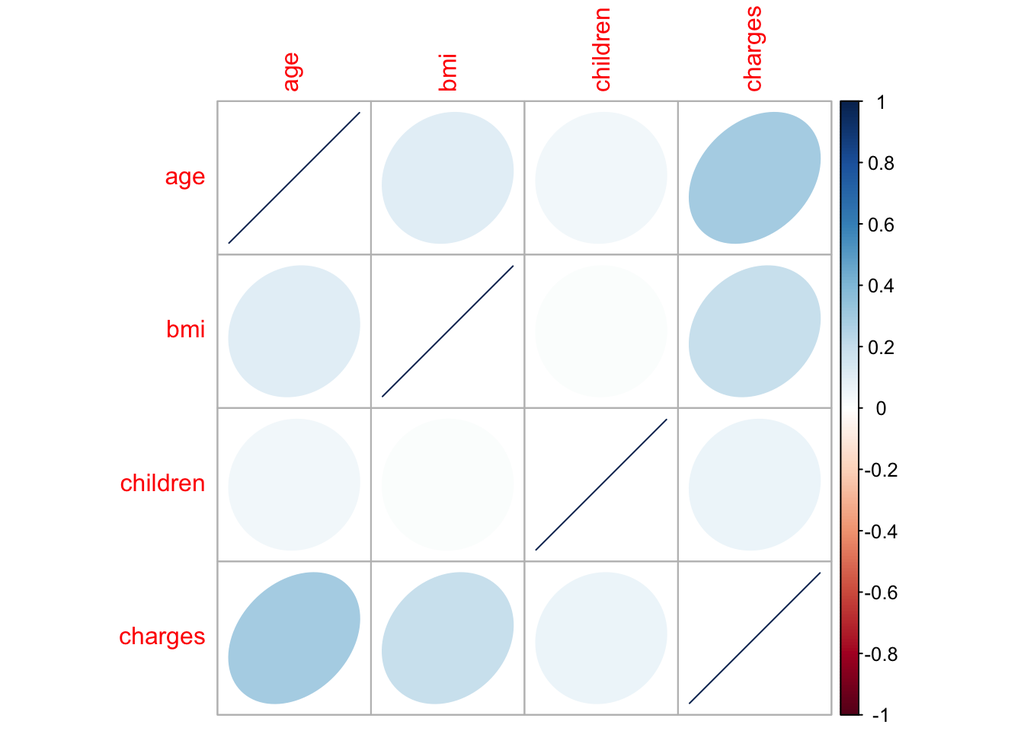

```r
  # corrplot.mixed(dataset.cor, upper = 'ellipse',lower='number')
  corrplot(dataset.cor, method = "ellipse",)
```

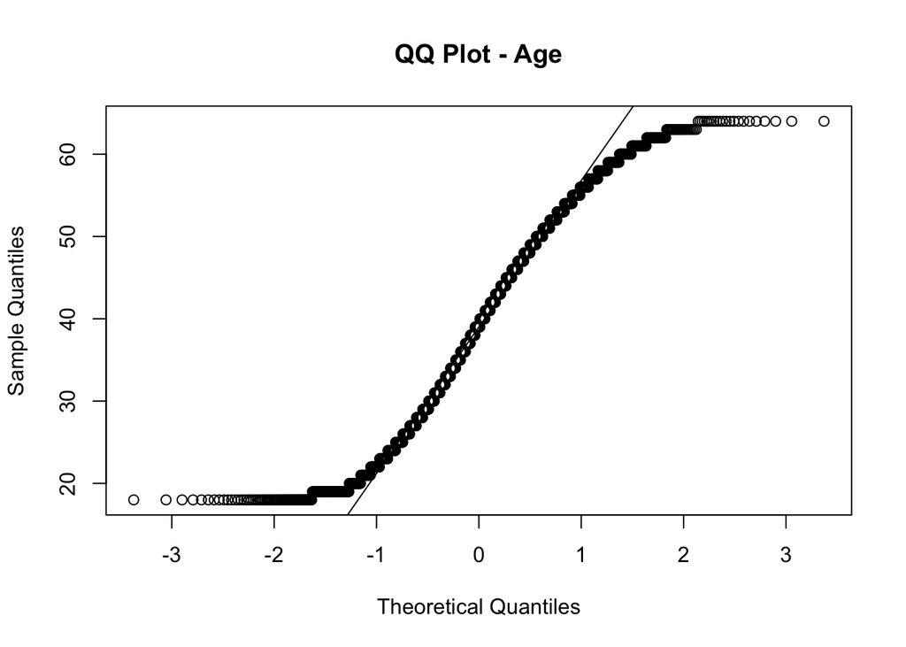

```r
qqnorm(dataset$age,
       main = "QQ Plot - Age")
qqline(dataset$age)
```

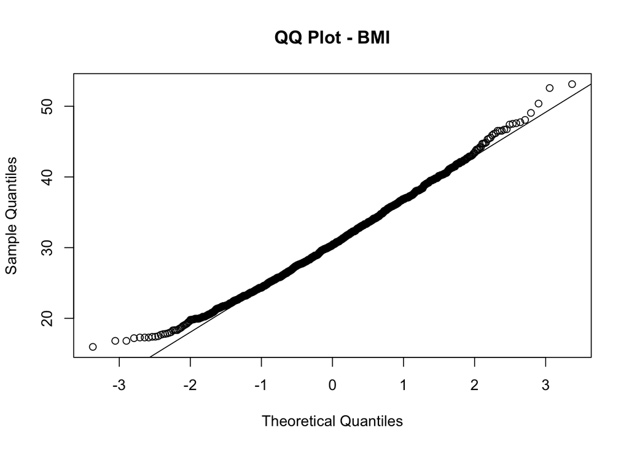

```r
qqnorm(dataset$bmi,
       main = "QQ Plot - BMI")
qqline(dataset$bmi)
```

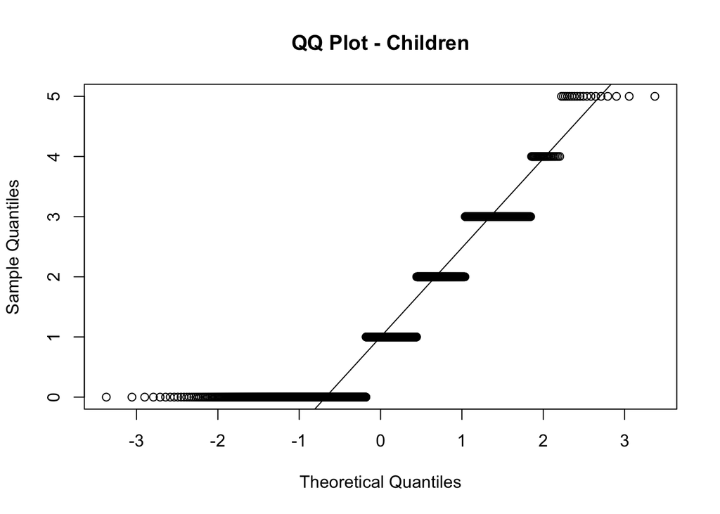

```r
qqnorm(dataset$children,
       main = "QQ Plot - Children")
qqline(dataset$children)
```

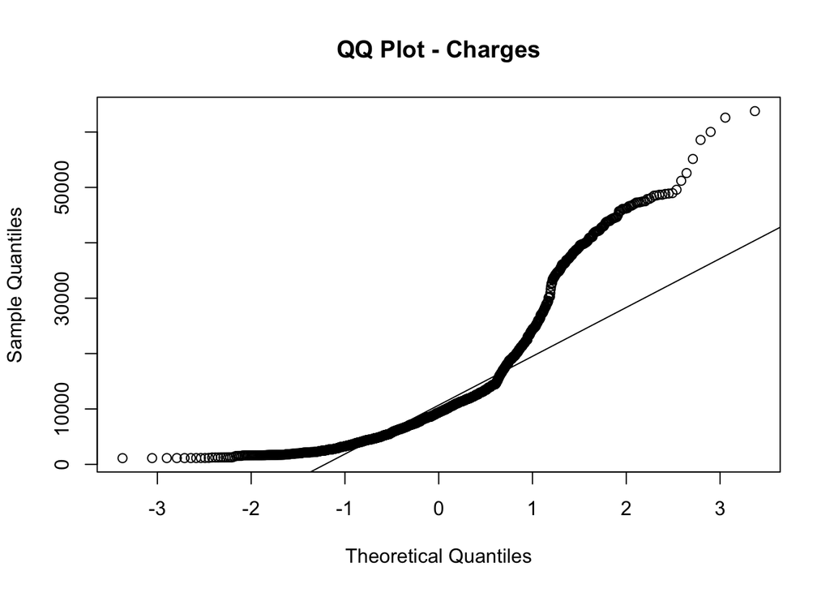

```r
qqnorm(dataset$charges,
       main = "QQ Plot - Charges")
qqline(dataset$charges)
```

```r
levels(dataset$sex)
```

```
## [1] "female" "male"
```

```r
levels(dataset$smoker)
```

```
## [1] "no"  "yes"
```

```r
levels(dataset$region)
```

```
## [1] "northeast" "northwest" "southeast" "southwest"
```

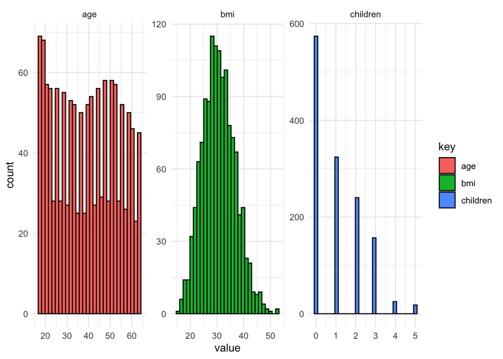

```r
dataset %>%
  select(-charges) %>%
  keep(is.numeric) %>%
  gather() %>%
  ggplot() +
  geom_histogram(aes(x=value, fill = key), color = "black") +
  facet_wrap(~ key, scales = "free") +
  theme_minimal()
```

## 3

### Full Model

```r
fullmodel <- lm(charges ~ ., data = dataset)
fullmodel
```

```
##
## Call:
## lm(formula = charges ~ ., data = dataset)
##
## Coefficients:
##     (Intercept)              age          sexmale              bmi
##        -11938.5            256.9           -131.3            339.2
##        children        smokeryes  regionnorthwest  regionsoutheast
##           475.5          23848.5           -353.0          -1035.0
## regionsouthwest
##          -960.1
```

charges = -11938.5 + 256.9(age) -131.3(sexmale) + bmi(bmi) + 475.5(children) + 23848.5(smokeryes) -353.0(regionNW) -1035.0(regionSE) -960.1(regionSW)

## 4

### Matrix method

```r
df <- data.frame(dataset_quantitative[, c("charges", "age", "bmi", "children")])
datarows <- nrow(df)
y_mat <- as.matrix(df)[, 1]
x1 <- df[, 2]
x2 <- df[, 3]
x3 <- df[, 4]
Ym <- matrix(y_mat, ncol = 1, byrow = T)
y_int <- data.frame(matrix(nrow = datarows, ncol = 1))
for(i in seq(1:datarows)){
  y_int[i, 1] = 1
}
df <- data_frame(y_int, x1, x2, x3)
Xm <- cbind(rep(1, datarows), as.matrix(df[, 2]), as.matrix(df[, 3]), as.matrix(df[, 4]))
# Lets find the transpose of matrix Xm
t(Xm) -> transposeXm
# The product of Xm and the transpose of Xm
  transposeXm%*%Xm-> ProDuct1
# Inverse of the matrix * transpose * Y
solve(ProDuct1)%*%transposeXm%*%Ym
```

```
##          [,1]
##    -6916.2433
## x1   239.9945
## x2   332.0834
## x3   542.8647
```

```r
# Calculate the intercept and slope
solve(ProDuct1)%*%transposeXm%*%Ym -> interceptandslope
```

charges = -6916.2433 + 239.9945(age) + 332.0834(bmi) + 542.8647(children)

```r
df <- data.frame("Fitted Values" =Xm %*% interceptandslope, "Residuals" =  Ym -  Xm %*% interceptandslope)
df
```

| Fitted.Values | Residuals |
| --- | --- |
| 6908.778 | 9976.1465 |
| 9160.977 | -7435.4248 |
| 12390.947 | -7941.4849 |
| 8543.527 | 13440.9435 |
| 10354.147 | -6487.2922 |
| 9071.411 | -5314.7896 |
| 15771.235 | -7530.6452 |
| 12804.139 | -5522.6331 |
| 12955.328 | -6548.9176 |
| 16064.459 | 12858.6777 |

[output cut: 1328 more lines]

## 5

#### Summary of full model

```r
summary(fullmodel)
```

```
##
## Call:
## lm(formula = charges ~ ., data = dataset)
##
## Residuals:
##      Min       1Q   Median       3Q      Max
## -11304.9  -2848.1   -982.1   1393.9  29992.8
##
## Coefficients:
##                 Estimate Std. Error t value Pr(>|t|)
## (Intercept)     -11938.5      987.8 -12.086  < 2e-16 ***
## age                256.9       11.9  21.587  < 2e-16 ***
## sexmale           -131.3      332.9  -0.394 0.693348
## bmi                339.2       28.6  11.860  < 2e-16 ***
## children           475.5      137.8   3.451 0.000577 ***
## smokeryes        23848.5      413.1  57.723  < 2e-16 ***
## regionnorthwest   -353.0      476.3  -0.741 0.458769
## regionsoutheast  -1035.0      478.7  -2.162 0.030782 *
## regionsouthwest   -960.0      477.9  -2.009 0.044765 *
## ---
## Signif. codes:  0 '***' 0.001 '**' 0.01 '*' 0.05 '.' 0.1 ' ' 1
##
## Residual standard error: 6062 on 1329 degrees of freedom
## Multiple R-squared:  0.7509, Adjusted R-squared:  0.7494
## F-statistic: 500.8 on 8 and 1329 DF,  p-value: < 2.2e-16
```

Adjusted R^2 value = 0.7494

**Remarks**

From the output summary above we can see that Age, BMI, children, smokeryes, region southeast, region southwest are all significant. Region southwest is close to being insignificant.

**Significance**

While sexmale, region northwest are insignificant at the 0.05 significance level.

The full models residual standard error is 6062 and in general the model is also significant as the pvalue for the entire model is below the 0.05 significance level.

## 6

### Confidence Interval

```r
model.fit <- lm(charges ~ ., dataset_quantitative)
# summary(model.fit)
confint(model.fit)
```

```
##                    2.5 %     97.5 %
## (Intercept) -10363.96835 -3468.5183
## age            196.26940   283.7195
## bmi            231.42538   432.7414
## children        36.26142  1049.4679
```

```r
# -6916.24 + 239.99age + 332.08bmi + 542.85children
age_upper <- 239.99 + 1.961744 * 22.29
age_lower <- 239.99 - 1.961744 * 22.29
bmi_upper <- 332.08 + 1.961744 * 51.31
bmi_lower <- 332.08 - 1.961744 * 51.31
# d.data <- tibble(X, Y)
conf.95 <- qt(p=.025, df=1334, lower.tail = FALSE)
conf.int.age <- cbind("Lower CI (Age)" = age_lower, "Upper CI (Age)" = age_upper)
conf.int.bmi <- cbind("Lower CI (BMI)" = bmi_lower, "Upper CI (BMI)" = bmi_upper)
```

```r
conf.int.age
```

```
##      Lower CI (Age) Upper CI (Age)
## [1,]       196.2627       283.7173
```

```r
conf.int.bmi
```

```
##      Lower CI (BMI) Upper CI (BMI)
## [1,]       231.4229       432.7371
```

## 7

```r
intercept_only <- lm(charges ~ 1, data=dataset)

#define model with all predictors
all <- lm(charges ~ ., data=dataset)

#perform forward stepwise regression
forward <- step(intercept_only, direction='forward', scope=formula(all), trace=0)
forward
```

```
##
## Call:
## lm(formula = charges ~ smoker + age + bmi + children + region,
##     data = dataset)
##
## Coefficients:
##     (Intercept)        smokeryes              age              bmi
##        -11990.3          23836.3            257.0            338.7
##        children  regionnorthwest  regionsoutheast  regionsouthwest
##           474.6           -352.2          -1034.4           -959.4
```

```r
#view results of forward stepwise regression
forward$anova
```

| Step | Df | Deviance | Resid. Df | Resid. Dev | AIC |
| --- | --- | --- | --- | --- | --- |
|  | NA | NA | 1337 | 196074221568 | 25160.18 |
| + smoker | -1 | 121519903622 | 1336 | 74554317947 | 23868.38 |
| + age | -1 | 19928201786 | 1335 | 54626116160 | 23454.24 |
| + bmi | -1 | 5112896646 | 1334 | 49513219514 | 23324.76 |
| + children | -1 | 434769398 | 1333 | 49078450117 | 23314.96 |
| + region | -3 | 233200844 | 1330 | 48845249273 | 23314.58 |

From the above stepwise output to get the best model, we can see that the model chosen was one that omitted the sex predictor as it was insignificant. While region was still included in the model, we chose to omit this predictor as well from our reduced model as looking at the summary table in section 5, the regions were either marginally significant, or were insignificant for the northwest region.

For these reasons we chose to remove region and sex from the reduced model so that we would only have the significant variables to predict charges.

```r
reducedmodel <- lm(charges ~ age + bmi + children + smoker, data = dataset)
summary(reducedmodel)
```

```
##
## Call:
## lm(formula = charges ~ age + bmi + children + smoker, data = dataset)
##
## Residuals:
##      Min       1Q   Median       3Q      Max
## -11897.9  -2920.8   -986.6   1392.2  29509.6
##
## Coefficients:
##              Estimate Std. Error t value Pr(>|t|)
## (Intercept) -12102.77     941.98 -12.848  < 2e-16 ***
## age            257.85      11.90  21.675  < 2e-16 ***
## bmi            321.85      27.38  11.756  < 2e-16 ***
## children       473.50     137.79   3.436 0.000608 ***
## smokeryes    23811.40     411.22  57.904  < 2e-16 ***
## ---
## Signif. codes:  0 '***' 0.001 '**' 0.01 '*' 0.05 '.' 0.1 ' ' 1
##
## Residual standard error: 6068 on 1333 degrees of freedom
## Multiple R-squared:  0.7497, Adjusted R-squared:  0.7489
## F-statistic: 998.1 on 4 and 1333 DF,  p-value: < 2.2e-16
```

```r
summary(fullmodel)
```

```
##
## Call:
## lm(formula = charges ~ ., data = dataset)
##
## Residuals:
##      Min       1Q   Median       3Q      Max
## -11304.9  -2848.1   -982.1   1393.9  29992.8
##
## Coefficients:
##                 Estimate Std. Error t value Pr(>|t|)
## (Intercept)     -11938.5      987.8 -12.086  < 2e-16 ***
## age                256.9       11.9  21.587  < 2e-16 ***
## sexmale           -131.3      332.9  -0.394 0.693348
## bmi                339.2       28.6  11.860  < 2e-16 ***
## children           475.5      137.8   3.451 0.000577 ***
## smokeryes        23848.5      413.1  57.723  < 2e-16 ***
## regionnorthwest   -353.0      476.3  -0.741 0.458769
## regionsoutheast  -1035.0      478.7  -2.162 0.030782 *
## regionsouthwest   -960.0      477.9  -2.009 0.044765 *
## ---
## Signif. codes:  0 '***' 0.001 '**' 0.01 '*' 0.05 '.' 0.1 ' ' 1
##
## Residual standard error: 6062 on 1329 degrees of freedom
## Multiple R-squared:  0.7509, Adjusted R-squared:  0.7494
## F-statistic: 500.8 on 8 and 1329 DF,  p-value: < 2.2e-16
```

### ANOVA

#### Test of Significance

```r
anova(reducedmodel, fullmodel)
```

|  | Res.Df | RSS | Df | Sum of Sq | F | Pr(>F) |
| --- | --- | --- | --- | --- | --- | --- |
| 1 | 1333 | 49078450117 | NA | NA | NA | NA |
| 2 | 1329 | 48839532844 | 4 | 238917273 | 1.625328 | 0.1654002 |

From the summary output we can see that both models are very close in their Multiple R^2 (reduced = 0.7497, full = 0.7509) and Adjusted R^2 values (reduced = 0.7489, full = 0.7494). Furthermore after running the anova on both models we can see that the anova test is not significant at the 0.05 significance level, and thus we choose the simpler/reduced model which only contains significant predictors.

Looking at our reduced model we can also interpret the predictors:

On average holding all else constant, for each year you get older, the charges (individual medical costs charged by the health insurance) increases by $257.85.

On average holding all else constant, for each additional child you have, the charges (individual medical costs charged by the health insurance) increases by $473.50.

On average holding all else constant, for each additional unit of BMI, the charges (individual medical costs charged by the health insurance) increases by $321.85.

On average holding all else constant, when you are a smoker you are charged (individual medical costs charged by the health insurance) $23811.40 more than if you were a non-smoker.

## 8

### Decision Tree

```r
library(tree)
tree.model <- tree(charges ~ ., dataset,
                   mindev = 0.005)
tree.model
```

```
## node), split, n, deviance, yval
##       * denotes terminal node
##
##  1) root 1338 1.961e+11 13270
##    2) smoker: no 1064 3.819e+10  8434
##      4) age < 42.5 596 1.320e+10  5399
##        8) children < 0.5 253 4.285e+09  3851 *
##        9) children > 0.5 343 7.860e+09  6541 *
##      5) age > 42.5 468 1.251e+10 12300
##       10) age < 51.5 199 4.071e+09 10190 *
##       11) age > 51.5 269 6.898e+09 13860 *
##    3) smoker: yes 274 3.637e+10 32050
##      6) bmi < 30.01 130 3.287e+09 21370
##       12) age < 41 73 8.796e+08 18470 *
##       13) age > 41 57 1.011e+09 25080 *
##      7) bmi > 30.01 144 4.859e+09 41690
##       14) age < 41.5 78 1.531e+09 38350 *
##       15) age > 41.5 66 1.431e+09 45640 *
```

```r
summary(tree.model)
```

```
##
## Regression tree:
## tree(formula = charges ~ ., data = dataset, mindev = 0.005)
## Variables actually used in tree construction:
## [1] "smoker"   "age"      "children" "bmi"
## Number of terminal nodes:  8
## Residual mean deviance:  21030000 = 2.797e+10 / 1330
## Distribution of residuals:
##    Min. 1st Qu.  Median    Mean 3rd Qu.    Max.
## -6640.0 -2219.0 -1233.0     0.0   374.3 23050.0
```

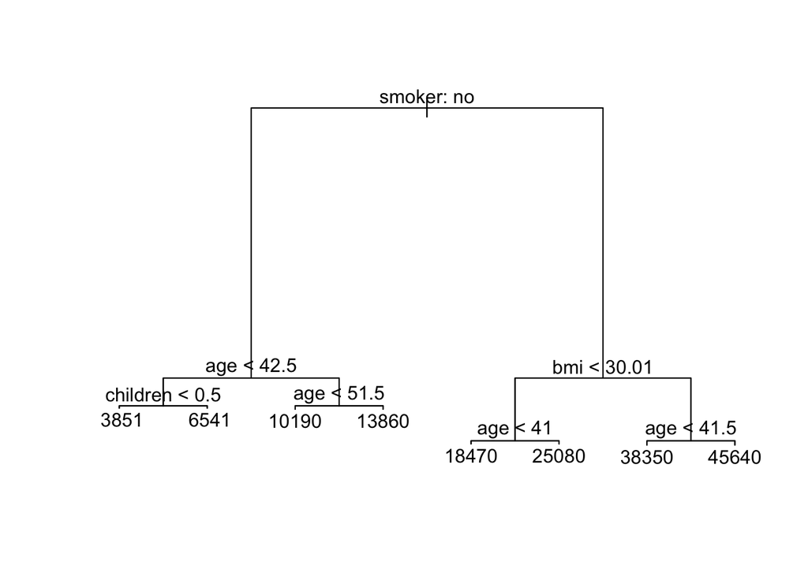

```r
plot(tree.model)
text(tree.model, pretty = 0)
```

We have used the **regression tree** here.

To determine the number of splittings to do, we use a parameter called **mindev**. The lower the mindev the more the trees grow. If we change the mindev to something larger than we used here, it will make the tree smaller than this.

The regression tree clearly revealed that those who smoke pay more on healthcare than those who do not smoke. Furthermore, if they have a BMI that is greater than 30.01 and are older than 41 years old, they spend the most on healthcare. From the tree, we also see that those who do not smoke but are over 51 years old tend to spend more on healthcare than those who are younger than 51 years and this is true because the body gets weaker and the immune systems too get weaker.

## 9

### Conclusion

Something we found interesting was that if you have more children you are charged more for medical bills. Initially we thought this was simple as more children means more people you need to pay for, however this is not the case as the charges are based on the specific individual. This means that people who have more children are also spending more on medical bills for themselves specifically and not the family which the analysis helped us highlight. Additionally we can see that a Smoker on average spends a lot more than nonsmokers, specifically $24,000. Both the multiple linear regression model and the regression tree helped highlight these aspects and enhanced our understanding on which factors affect medical expenses the most.